# Análise de Gastos de Deputados: Suas Perguntas

Matheus Freitas

5 de setembro de 2018

Utilizando os mesmos dados utilizados na análise anterior, Análise de Gastos de Deputados: Nossas Perguntas, temos agora como objetivo a criação de duas perguntas que utilizem medidas estatísticas e iremos responde-las ao longo dessa análise.

Não iremos introduzir os dados novamente, para qualquer explicação sobre o que está sendo trabalhado aqui, observar o [Análise de Gastos de Deputados: Nossas Perguntas](https://rpubs.com/matheusfreitaas/416584)

# Existe uma relação entre a média de gastos dos deputados de cada partido e o seu tamanho?

Podemos imaginar que os maiores partidos possuam um gasto médio maior do que os menores partidos, iremos analisar isso abaixo.

```r
gastos_deputado_partido <- dados %>%
  select(sgPartido, valorLiquido, nomeParlamentar) %>%
  group_by(nomeParlamentar, sgPartido) %>%
  summarise(valorLiquido = sum(valorLiquido))

gastos_medio_partido <- gastos_deputado_partido %>%
  group_by(sgPartido) %>%
  summarise(gastoMedio = mean(valorLiquido),
            tamanhoPartido = n())

plot_ly(data = gastos_medio_partido,
        x = ~tamanhoPartido,
        y = ~gastoMedio,
        color = ~sgPartido,
        type = "bar",
        width = )
```

[interactive chart not shown]

- Para analisar partidos especificos o usuário precisa apenas clicar em algum dos partidos listados ao lado do gráfico.
- Consideramos aqui que o tamanho do partido é dado pela quantidade de Deputados do mesmo.

Analisando este gráfico podemos afirmar que não existe uma relação entre o tamanho do partido e o seu gasto médio da CEAP, na verdade parece ser mais comum um maior gasto em partidos menores.

# Qual a média de gastos mensais dos partidos na Paraíba?

Estimamos uma média de cinco mil reais por mês para cada partido no Estado da Paraíba.

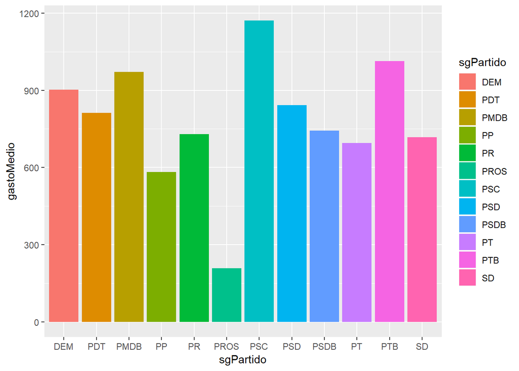

```r
gasto_mensal_paraiba <- dados %>%
  select(sgPartido, dataEmissao, sgUF, valorLiquido) %>%
  filter(sgUF == "PB")

gasto_mensal_paraiba$dataEmissao <- date(gasto_mensal_paraiba$dataEmissao)
gasto_mensal_paraiba$mes <- month(gasto_mensal_paraiba$dataEmissao)

gasto_mensal_paraiba <- gasto_mensal_paraiba %>%
  group_by(sgPartido) %>%
  summarise(gastoMedio = mean(valorLiquido))

ggplot(data = gasto_mensal_paraiba,
       mapping = aes(x = sgPartido,
                     y = gastoMedio,
                     fill = sgPartido)) +
  geom_bar(stat = "identity")
```

No gráfico acima podemos ver que a estimativa feita anteriormente não condiz com a realidade que varia, em geral, entre 600 até 1200 reais mensais.